# Setting up R

We will use the R language for our sessions. You can do most of the practicals in the same amount of work in python (or matlab, mathematica…), but later on we will use statistical packages that are only implemented in R. For each session I will give you the solution in R, and you are free to use the language of your choice for the projects.

If you want to use R you can download it from here : https://cran.r-project.org/bin/ .

I also advise to use Rstudio, a user-friendly environment and editor : https://www.rstudio.com/products/rstudio/download/ .

If you are not familiar with R, you can learn the basics here http://www.sthda.com/english/wiki/r-basics-quick-and-easy .

Once R is installed you will need to install an additional package that we will use for this session. Copy and paste this line in your R command prompt to run it :

```r
install.packages("igraph", dependencies = TRUE)
```

You can find its documentation here : https://igraph.org/r/doc/ (I suggest you keep it open in a tab!)

# Topoligical measures with igraph

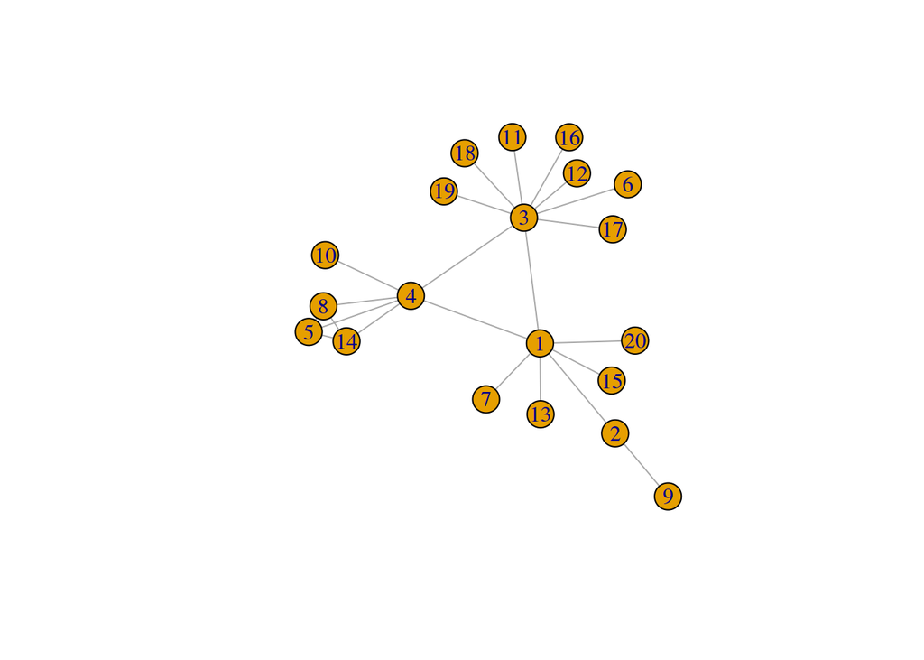

```r
library(igraph)
g = read_graph("simple_graph.txt")
g = as.undirected(g)
plot(g)
```

```r
V(g)
```

```
## + 20/20 vertices, from 53daa44:
##  [1]  1  2  3  4  5  6  7  8  9 10 11 12 13 14 15 16 17 18 19 20
```

```r
E(g)
```

```
## + 23/23 edges from 53daa44:
##  [1] 1-- 2 1-- 3 1-- 4 3-- 4 4-- 5 3-- 6 1-- 7 4-- 8 5-- 8 2-- 9 4--10
## [12] 3--11 3--12 1--13 4--14 5--14 8--14 1--15 3--16 3--17 3--18 3--19
## [23] 1--20
```

1. Find two different ways to write down this network’s topology

```r
print("Adjacency matrix")
```

```
## [1] "Adjacency matrix"
```

```r
print("Adjacency list")
```

```
## [1] "Adjacency list"
```

2. What are the degrees of the nodes 1, 2, 5 ? Specify in, out and total degree if applicable.
3. How many connected components are there ? How many cliques of more thant 3 nodes ?
4. What is the betweenness centrality of the node 5 ? Which has a higher centrality : 3 or 4 ? Which nodes have non-zero betweenness ?
5. What are the clustering coefficients of the nodes 2, 4, 5 ?

## Algorithms

Here you can try to code your solutions in R for the three algorithmic problems of section 1.2. Work with your neighbours or ask me if you need help.

Keep in mind that most useful functions are already implemented in `igraph` or other packages. For our examples, you can read the documentationn of the functions `shortest_paths`, all `*.game` functions (for example `erdos.renyi.game`), and `as.directed`, `is_dag` to test for acyclicity.

## Guess the network

In this section you will find the code used to generate the three networks, the different plots and the asnwers to the final two questions.

```r
N_nodes = 1000
N_edges = 3000
g1 = erdos.renyi.game(n = N_nodes, p.or.m = N_edges/(N_nodes*(N_nodes-1)/2))
g2 = barabasi.game(n = N_nodes, m=N_edges/N_nodes, power = 1, directed=F)
g3 = watts.strogatz.game(1, N_nodes, N_edges/N_nodes, 0.1)
```

```r
dd_g1 = degree_distribution(g1)
dd_g2 = degree_distribution(g2)
dd_g3 = degree_distribution(g3)
```

```r
dd_g1[dd_g1==0] = NA
dd_g2[dd_g2==0] = NA
dd_g3[dd_g3==0] = NA
```

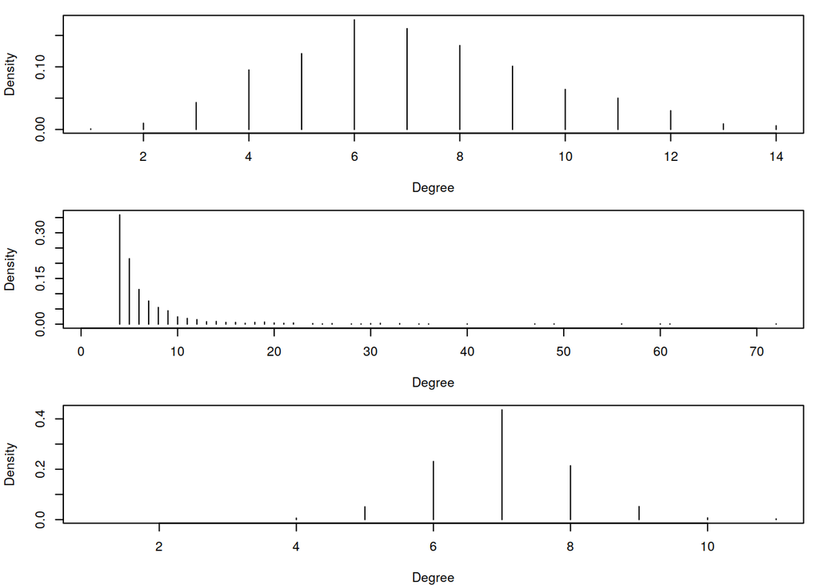

```r
#pdf("dd_hist.pdf", width=2.5, height=7)
par(mfrow=c(3,1), mar=c(4,4.1,1,1))
plot(1:length(dd_g1), dd_g1, type='h', xlab = 'Degree', ylab = 'Density')
plot(1:length(dd_g2), dd_g2, type='h', xlab = 'Degree', ylab = 'Density')
plot(1:length(dd_g3), dd_g3, type='h', xlab = 'Degree', ylab = 'Density')
```

```r
#dev.off()
```

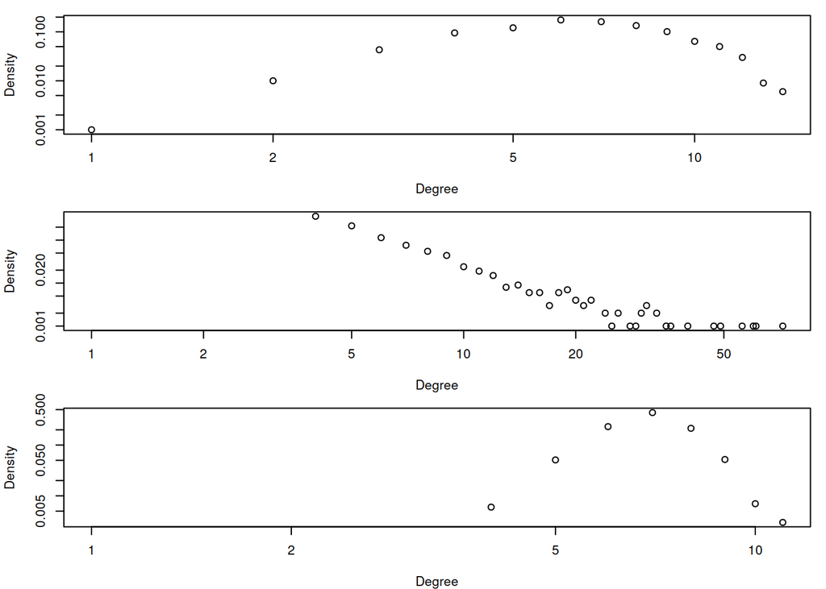

```r
#pdf("dd_log.pdf", width=2.5, height=7)
par(mfrow=c(3,1), mar=c(4,4.1,1,1))
plot(1:length(dd_g1), dd_g1, type='p', log="xy", xlab = 'Degree', ylab = 'Density')
plot(1:length(dd_g2), dd_g2, type='p', log="xy", xlab = 'Degree', ylab = 'Density')
plot(1:length(dd_g3), dd_g3, type='p', log="xy", xlab = 'Degree', ylab = 'Density')
```

```r
#dev.off()
```

```r
average.path.length(g1)
```

```
## [1] 4.03932
```

```r
average.path.length(g2)
```

```
## [1] 3.593047
```

```r
average.path.length(g3)
```

```
## [1] 5.221133
```

```r
transitivity(g1)
```

```
## [1] 0.006123462
```

```r
transitivity(g2)
```

```
## [1] 0.0187863
```

```r
transitivity(g3)
```

```
## [1] 0.3193218
```

```r
# This function was used to plot the graphs examples. Do not try to plot big graphs ! (more than a few hundred nodes)
plot_graph = function(g){
    V(g)$size = (degree(g)+1)*0.7
    V(g)$frame.color <- "white"
    plot(g, vertex.label=NA, edge.width=0.5)
}
```

```r
#pdf("example_g1.pdf", width=3, height=3)
#par(mgp=c(2.2,0.45,0), tcl=-0.4, mar=c(0,0,0,0))
plot_graph(g1)
```

[figure not shown]

```r
#dev.off()

#pdf("example_g2.pdf", width=3, height=3)
#par(mgp=c(2.2,0.45,0), tcl=-0.4, mar=c(0,0,0,0))
plot_graph(g2)
```

[output not shown]

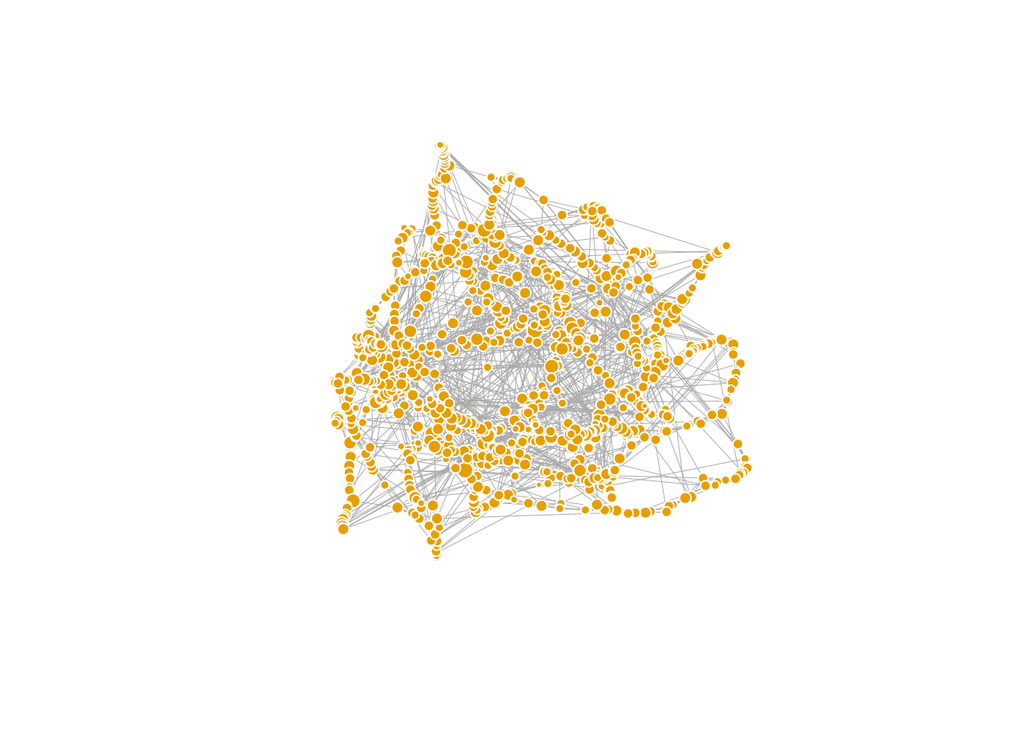

```r
#dev.off()

#pdf("example_g3.pdf", width=3, height=3)
#par(mgp=c(2.2,0.45,0), tcl=-0.4, mar=c(0,0,0,0))
plot_graph(g3)
```

```r
#dev.off()
```

# Network inference using ARACNE

Finally, you can use another package called `minet` to run the ARACNE method on the toy mutual information matrix used as example.

```r
mi_matrix = read.table("MI_matrix.txt")
mi_matrix
```

```
##           x1        x2        x3        x4        x5        x6
## x1 0.0000000 0.2319904 0.3897391 0.2221233 0.1548920 0.1935037
## x2 0.2319904 0.0000000 0.5557764 0.3306445 0.2370350 0.2834041
## x3 0.3897391 0.5557764 0.0000000 0.5303785 0.3443858 0.4219912
## x4 0.2221233 0.3306445 0.5303785 0.0000000 0.7107990 0.9639047
## x5 0.1548920 0.2370350 0.3443858 0.7107990 0.0000000 1.0190701
## x6 0.1935037 0.2834041 0.4219912 0.9639047 1.0190701 0.0000000
```

```r
library(minet)
```

```r
net = aracne(mim = mi_matrix)
net
```

```
##           x1        x2        x3        x4      x5        x6
## x1 0.0000000 0.0000000 0.3897391 0.0000000 0.00000 0.0000000
## x2 0.0000000 0.0000000 0.5557764 0.0000000 0.00000 0.0000000
## x3 0.3897391 0.5557764 0.0000000 0.5303785 0.00000 0.0000000
## x4 0.0000000 0.0000000 0.5303785 0.0000000 0.00000 0.9639047
## x5 0.0000000 0.0000000 0.0000000 0.0000000 0.00000 1.0190701
## x6 0.0000000 0.0000000 0.0000000 0.9639047 1.01907 0.0000000
```

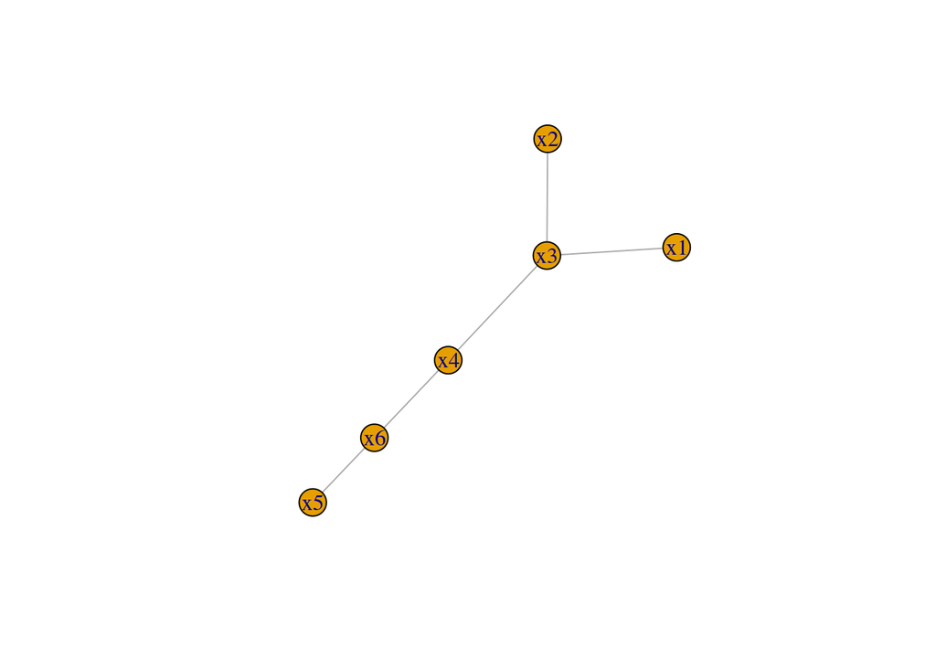

```r
plot(graph_from_adjacency_matrix(net, mode="undirected", weighted = TRUE))
```